# Bike-share Analysis

Sam Otu

2023-11-01

## *Project Summary*

In this project, I demonstrate essential data analysis skills by efficiently *organizing, cleaning, transforming, analyzing,* and *visualizing* bike ride data for a fictional bike share company, **Ridez**. This endeavor aims to provide actionable insights, enabling data-driven decision-making to optimize revenue and improve business strategies at Ridez.

The project tries to answer the question, ‘How different are annual members from casual riders at Ridez?’ This question focuses on understanding the differences between two important customer groups: annual members and casual riders. By analyzing and comparing these groups, I provide valuable insights that Ridez can use to make data-driven decisions and potentially tailor their services or marketing strategies to better serve each group.

## *Data source*

I used [bike-ride data for 2022](https://divvy-tripdata.s3.amazonaws.com/index.html) made available by Motivate International Inc. under this [licence](https://divvybikes.com/data-license-agreement)

## Ridez 2022 Bike-ride Data Analysis

I begin by loading the needed libraries:

```r
library(tidyverse)
library(skimr)
library(janitor)
```

### Downloading/organizing files

At the time of doing this, data for 2022 was accessible in the form of individual zip files for each month, totaling 12 zip files. The subsequent code facilitates the download and extraction of these files.

```r
#declaring variables
cnt <- sprintf("%02d", 1:12)
urls <- list()
dest_dir <- "C:/Users/otusa/Desktop/Data Analyst/Capstone Project/Dowloads"
unzip_dir <- "C:/Users/otusa/Desktop/Data Analyst/Capstone Project/CSV"

#setting up download links for 12 files
for (x in 1:12) {
  link <- "https://divvy-tripdata.s3.amazonaws.com/2022" %>%
  paste(cnt[x], sep = "") %>%
  paste("-divvy-tripdata.zip", sep = "")
  urls <- c(urls, link)
}

#Download zip files
for (url in urls) {
  filename <- basename(url)  # Extract the filename from the URL
  dest_file <- file.path(dest_dir, filename)  # Define the destination file path
  download.file(url, dest_file, mode = "wb")
}

#Unzip files
zip_files <- list.files(dest_dir, pattern = ".zip", full.names = TRUE) #list downloaded zip files
for (file in zip_files) {
  unzip(file, exdir = unzip_dir) #unzip csv files into working directory
}
```

```r
setwd("C:/Users/otusa/Desktop/Data Analyst/Capstone Project/CSV")
trips_csv <- list.files() # list of csv file names
dfs <- list()   #list of dataframes from each csv(month)

#Load CSVs into data frames df1:df12
for (cnt in 1:12) {
  dfs[cnt]  <- paste("df", cnt, sep = "")
  df <- read_csv(trips_csv[cnt])
  dfs[[cnt]] <- df
}
```

### Checking for Consistency in Column names

```r
janitor::compare_df_cols(dfs, return = "mismatch")
```

```
##  [1] column_name dfs_1       dfs_2       dfs_3       dfs_4       dfs_5
##  [7] dfs_6       dfs_7       dfs_8       dfs_9       dfs_10      dfs_11
## [13] dfs_12
## <0 rows> (or 0-length row.names)
```

### Organizing datasets into one dataframe

```r
df_all <- dfs[[1]]  # Initialize with the first data frame

for (cnt in 2:length(dfs)) {
  df_all <- rbind(df_all, dfs[[cnt]])
}
head(df_all)
```

```
## # A tibble: 6 × 13
##   ride_id          rideable_type started_at          ended_at
##   <chr>            <chr>         <dttm>              <dttm>
## 1 C2F7DD78E82EC875 electric_bike 2022-01-13 11:59:47 2022-01-13 12:02:44
## 2 A6CF8980A652D272 electric_bike 2022-01-10 08:41:56 2022-01-10 08:46:17
## 3 BD0F91DFF741C66D classic_bike  2022-01-25 04:53:40 2022-01-25 04:58:01
## 4 CBB80ED419105406 classic_bike  2022-01-04 00:18:04 2022-01-04 00:33:00
## 5 DDC963BFDDA51EEA classic_bike  2022-01-20 01:31:10 2022-01-20 01:37:12
## 6 A39C6F6CC0586C0B classic_bike  2022-01-11 18:48:09 2022-01-11 18:51:31
## # ℹ 9 more variables: start_station_name <chr>, start_station_id <chr>,
## #   end_station_name <chr>, end_station_id <chr>, start_lat <dbl>,
## #   start_lng <dbl>, end_lat <dbl>, end_lng <dbl>, member_casual <chr>
```

### Explore data

```r
skim_without_charts(df_all)
```

Data summary

| Name | df_all |
| --- | --- |
| Number of rows | 5667717 |
| Number of columns | 13 |
| _______________________ |  |
| Column type frequency: |  |
| character | 7 |
| numeric | 4 |
| POSIXct | 2 |
| ________________________ |  |
| Group variables | None |

**Variable type: character**

| skim_variable | n_missing | complete_rate | min | max | empty | n_unique | whitespace |
| --- | --- | --- | --- | --- | --- | --- | --- |
| ride_id | 0 | 1.00 | 16 | 16 | 0 | 5667717 | 0 |
| rideable_type | 0 | 1.00 | 11 | 13 | 0 | 3 | 0 |
| start_station_name | 833064 | 0.85 | 7 | 64 | 0 | 1674 | 0 |
| start_station_id | 833064 | 0.85 | 3 | 44 | 0 | 1313 | 0 |
| end_station_name | 892742 | 0.84 | 9 | 64 | 0 | 1692 | 0 |
| end_station_id | 892742 | 0.84 | 3 | 44 | 0 | 1317 | 0 |
| member_casual | 0 | 1.00 | 6 | 6 | 0 | 2 | 0 |

**Variable type: numeric**

| skim_variable | n_missing | complete_rate | mean | sd | p0 | p25 | p50 | p75 | p100 |
| --- | --- | --- | --- | --- | --- | --- | --- | --- | --- |
| start_lat | 0 | 1 | 41.90 | 0.05 | 41.64 | 41.88 | 41.90 | 41.93 | 45.64 |
| start_lng | 0 | 1 | -87.65 | 0.03 | -87.84 | -87.66 | -87.64 | -87.63 | -73.80 |
| end_lat | 5858 | 1 | 41.90 | 0.07 | 0.00 | 41.88 | 41.90 | 41.93 | 42.37 |
| end_lng | 5858 | 1 | -87.65 | 0.11 | -88.14 | -87.66 | -87.64 | -87.63 | 0.00 |

**Variable type: POSIXct**

| skim_variable | n_missing | complete_rate | min | max | median | n_unique |
| --- | --- | --- | --- | --- | --- | --- |
| started_at | 0 | 1 | 2022-01-01 00:00:05 | 2022-12-31 23:59:26 | 2022-07-22 15:03:59 | 4745862 |
| ended_at | 0 | 1 | 2022-01-01 00:01:48 | 2023-01-02 04:56:45 | 2022-07-22 15:24:44 | 4758633 |

### Clean/Prep data for Analysis

The following code filters the data by selecting relevant columns and creating new ones for the analysis

```r
df_new <- select(df_all, "rideable_type", "member_casual")
df_new$date <- as.Date(df_all$started_at) #Format date as yyyy-mm-dd
df_new$month <- format(df_new$date, "%b") #Add column for month
df_new$day <- format(df_new$date, "%a") #Add column for Day of week
df_new$ride_len <- difftime(df_all$ended_at, df_all$started_at, units= "mins") #Add column for ride length
```

Check data after transformation

```r
skim_without_charts(df_new)
```

Data summary

| Name | df_new |
| --- | --- |
| Number of rows | 5667717 |
| Number of columns | 6 |
| _______________________ |  |
| Column type frequency: |  |
| character | 4 |
| Date | 1 |
| difftime | 1 |
| ________________________ |  |
| Group variables | None |

**Variable type: character**

| skim_variable | n_missing | complete_rate | min | max | empty | n_unique | whitespace |
| --- | --- | --- | --- | --- | --- | --- | --- |
| rideable_type | 0 | 1 | 11 | 13 | 0 | 3 | 0 |
| member_casual | 0 | 1 | 6 | 6 | 0 | 2 | 0 |
| month | 0 | 1 | 3 | 3 | 0 | 12 | 0 |
| day | 0 | 1 | 3 | 3 | 0 | 7 | 0 |

**Variable type: Date**

| skim_variable | n_missing | complete_rate | min | max | median | n_unique |
| --- | --- | --- | --- | --- | --- | --- |
| date | 0 | 1 | 2022-01-01 | 2022-12-31 | 2022-07-22 | 365 |

**Variable type: difftime**

| skim_variable | n_missing | complete_rate | min | max | median | n_unique |
| --- | --- | --- | --- | --- | --- | --- |
| ride_len | 0 | 1 | -10353.35 mins | 41387.25 mins | 10.28 mins | 22312 |

Checking data revealed row with ride duration <= 0.The following code removes these rows and stores the resulting data in a new dataframe *df_clean* for the purposes of my analysis.

```r
irrel_rows <- sum(df_new$ride_len<= 0)
paste(irrel_rows, "rows have ride_len <= 0" )
```

```
## [1] "531 rows have ride_len <= 0"
```

```r
df_clean <- df_new[(df_new$ride_len > 0),]
df_clean$ride_len <- as.numeric(df_clean$ride_len) #Convert ride_len to numeric
write.csv(df_clean, "C:/Users/otusa/Desktop/Data Analyst/Capstone Project/CSV/2022_RidezData.csv")  #save data frame to csv file
```

```r
summarise(df_clean, number = n(),
           avg_ride_len = mean(ride_len),
           min_ride_len = min(ride_len),
           max_ride_len = max(ride_len),
         total_ride_len = sum(ride_len),
           .by = member_casual)
```

```
## # A tibble: 2 × 6
##   member_casual  number avg_ride_len min_ride_len max_ride_len total_ride_len
##   <chr>           <int>        <dbl>        <dbl>        <dbl>          <dbl>
## 1 casual        2321769         29.1       0.0167       41387.      67675695.
## 2 member        3345417         12.7       0.0167        1560.      42536503.
```

```r
df_clean %>% summarise( number = n(),
           avg_ride_len = mean(ride_len),
           min_ride_len = min(ride_len),
           max_ride_len = max(ride_len),
         total_ride_len = sum(ride_len),
           .by = month) %>%
arrange(desc(total_ride_len))
```

```
## # A tibble: 12 × 6
##    month number avg_ride_len min_ride_len max_ride_len total_ride_len
##    <chr>  <int>        <dbl>        <dbl>        <dbl>          <dbl>
##  1 Jul   823416         21.4       0.0167       34209.      17615077.
##  2 Jun   769138         22.7       0.0167       35821.      17447948.
##  3 Aug   785855         20.7       0.0167       28129.      16235250.
##  4 Sep   701267         19.3       0.0167       27698.      13553646.
##  5 May   634810         21.1       0.0167       36258.      13394027.
##  6 Oct   558620         17.4       0.0167       41387.       9696576.
##  7 Apr   371218         17.6       0.0167       21122.       6547109.
##  8 Mar   284024         18.5       0.0167       34354.       5254001.
##  9 Nov   337677         14.2       0.0167       19613.       4783639.
## 10 Dec   181792         13.5       0.0167       19157.       2454603.
## 11 Feb   115604         14.2       0.0167       10906.       1646309.
## 12 Jan   103765         15.3       0.0167       29271.       1584014.
```

```r
df_clean %>% summarise( number = n(),
           avg_ride_len = mean(ride_len),
           min_ride_len = min(ride_len),
           max_ride_len = max(ride_len),
         total_ride_len = sum(ride_len),
           .by = day) %>%
arrange(desc(total_ride_len))
```

```
## # A tibble: 7 × 6
##   day   number avg_ride_len min_ride_len max_ride_len total_ride_len
##   <chr>  <int>        <dbl>        <dbl>        <dbl>          <dbl>
## 1 Sat   916376         23.7       0.0167       41387.      21700417.
## 2 Sun   776161         24.1       0.0167       36258.      18681925.
## 3 Fri   801718         19.0       0.0167       32403.      15239265.
## 4 Thu   841512         17.2       0.0167       31024.      14445527
## 5 Mon   750954         18.5       0.0167       32035.      13912355.
## 6 Wed   798175         16.5       0.0167       35821.      13131846.
## 7 Tue   782290         16.7       0.0167       31086.      13100863.
```

### Data Visualization

I used bar charts to show the daily and seasonal variations in patronage, while highlighting the differences between the two groups.

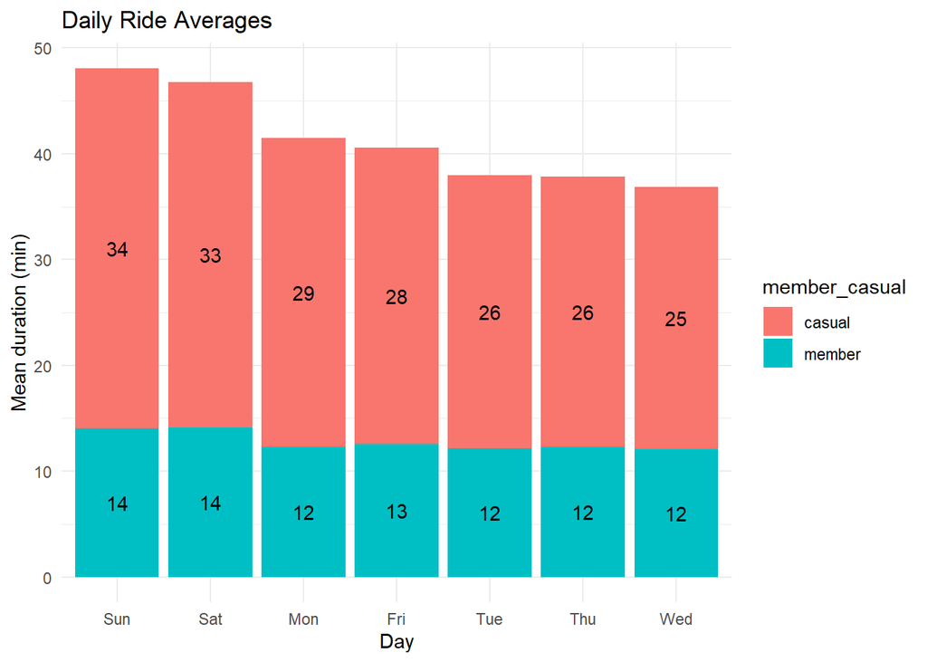

```r
df_clean %>%
  group_by(member_casual,day) %>%
  summarise(num_rides = n(), avg_ride_len = mean(ride_len)) %>%
  ggplot(aes(x=reorder(day, -avg_ride_len), y=avg_ride_len, fill=member_casual))+geom_col()+
  geom_text(aes(label = round(avg_ride_len, 0), group = member_casual), position = position_stack(vjust = 0.5))+
  labs(x="Day", y="Mean duration (min)", title = "Daily Ride Averages")+ theme_minimal()
```

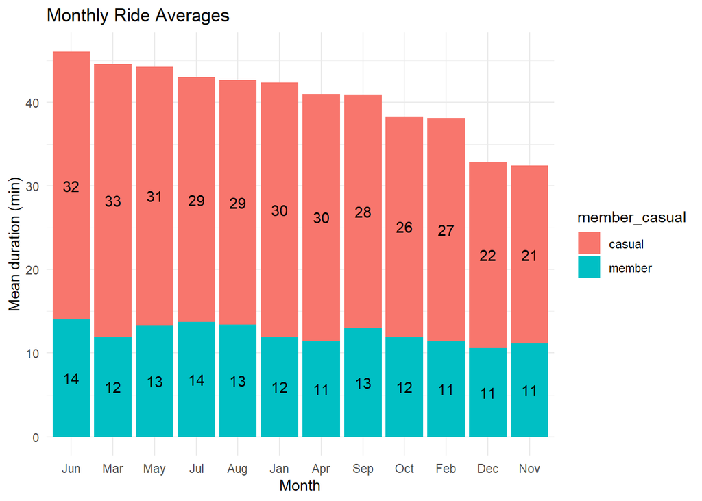

```r
df_clean %>%
  group_by(member_casual, month) %>%
  summarise(num_rides = n(), avg_ride_len = mean(ride_len)) %>%
  ggplot(aes(x=reorder(month, -avg_ride_len), y=avg_ride_len, fill=member_casual))+geom_col()+
  geom_text(aes(label = round(avg_ride_len, 0), group = member_casual), position = position_stack(vjust = 0.5))+
  labs(x="Month", y="Mean duration (min)", title = "Monthly Ride Averages")+ theme_minimal()
```

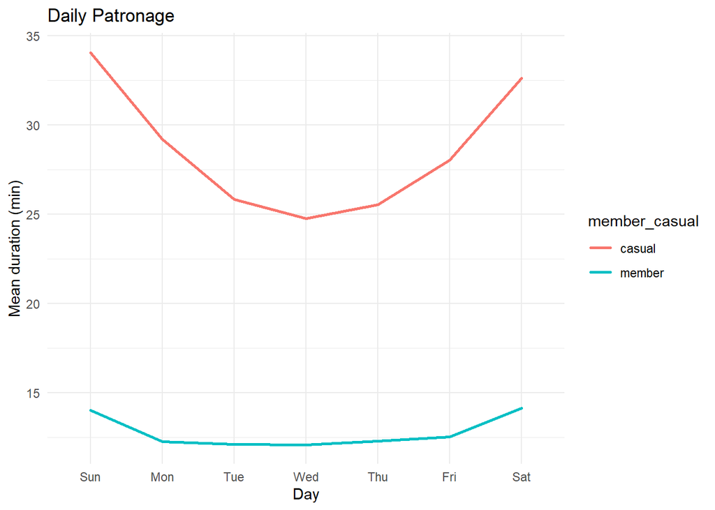

```r
day_ord<-c("Sun","Mon", "Tue", "Wed", "Thu", "Fri", "Sat")
df_clean %>%
  group_by(member_casual,day) %>%
  summarise(avg_len = mean(ride_len)) %>%
  ggplot(aes(x=factor(day, day_ord), y= avg_len, group= member_casual, color= member_casual))+
  geom_line(linewidth=1, lineend= "round")+
  labs(x="Day", y="Mean duration (min)", title = "Daily Patronage")+ theme_minimal()
```

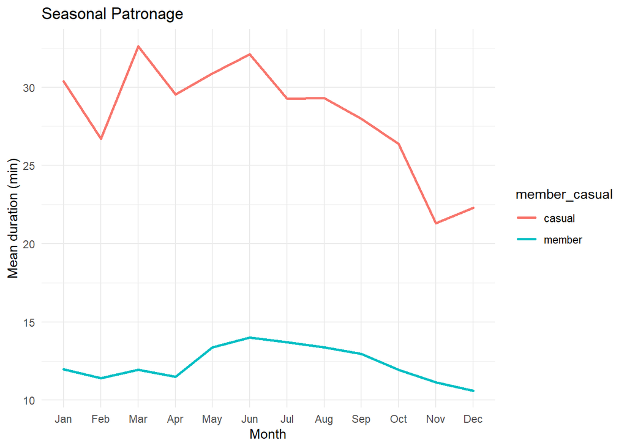

```r
month_ord<- unique(df_clean$month)
df_clean %>%
  group_by(member_casual,month) %>%
  summarise(avg_len = mean(ride_len)) %>%
  ggplot(aes(x= factor(month, month_ord), y= avg_len, group= member_casual, color= member_casual))+
  geom_line(linewidth=1, lineend= "round")+
  labs(x="Month", y="Mean duration (min)", title = "Seasonal Patronage")+ theme_minimal()
```